# Modeling_Poisson_Analysis

tianwei zhao 12/9/2021

```r
library(tidyverse)
library(dplyr)
```

## Goal

My goal was to compare the rate of death in a gunshoot in recent years,such as 2019 to the same month in 2020 (e.g., rate of death in January 2019 v. rate of death in January 2020).Additionally,I stratified these rate ratio estimates by borough.

To accomplish this, I filtered the tidy data to create one dataset for male victims and one for female victims.I created nested datasets by month, and, in each of these datasets, I mapped Poisson models to extract rate ratio estimates for number of death in each borough. Finally, I unnessted these models to extract the desired coefficients: rate ratios and standard errors (used to compute 95% confidence intervals).

tidy functions to filter either male or female victims.

```r
mydata = read.csv("data/NYPD_Shooting_Incident_Data_Clean.csv") %>%
mutate(
    statistical_murder_flag = as.character(statistical_murder_flag),
    statistical_murder_flag = recode(statistical_murder_flag, "FALSE" = "1","TRUE" = "0")
  ) %>%
  mutate(statistical_murder_flag = as.numeric(statistical_murder_flag))


male_based = mydata%>%
  filter(vic_sex == "male")

female_based = mydata %>%
  filter(vic_sex == "female")

month_df=
  tibble(
    month = 1:12,
    month_name = factor(month.name, ordered = TRUE, levels = month.name)
  )
```

### For male victims in differnent boro death rate

```r
male_data = male_based %>%
  filter(year %in% c(2019,2020)) %>%
  mutate(boro = str_to_title(boro)) %>%
  group_by(year) %>%
  mutate(year = year - 2019) %>%
  nest(data = -month) %>%
  mutate(models = map(data, ~glm( statistical_murder_flag~ year:boro,
                                 family = "poisson", data = .x)),
         models = map(models, broom::tidy)) %>%
  dplyr::select(-data) %>%
  unnest(models) %>%
  dplyr::select(month, term, estimate, std.error, p.value) %>%
  mutate(term = str_replace(term, "year:boro", "Boro: ")) %>%
  left_join(month_df, by = "month") %>%
  dplyr::select(-month) %>%
  rename(month = month_name) %>%
  dplyr::select(month, everything())
```

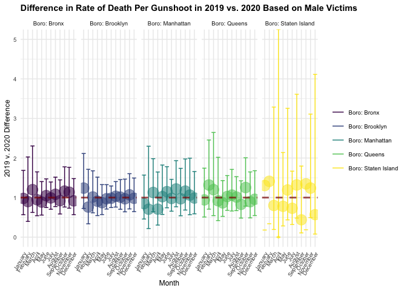

```r
male_data %>%
  filter(term != "(Intercept)") %>%
  mutate(term = str_replace(term, "2019 v. 2020, ", "")) %>%
  ggplot(aes(x = month, y = exp(estimate), color = term)) +
  geom_point(show.legend = FALSE, aes(size = estimate, alpha = .7)) +
  geom_errorbar(aes(ymin = exp(estimate - (1.96*std.error)),
                    ymax = exp(estimate + (1.96*std.error)))) +
  geom_hline(yintercept = 1, linetype="dashed",
                color = "darkred", size = 1, alpha = .7) +
  labs(
    title = "Difference in Rate of Death Per Gunshoot in 2019 vs. 2020 Based on Male Victims",
    x = "Month",
    y = "2019 v. 2020 Difference"
  ) +
  ylim(0, 5) +
  theme(legend.position="right", legend.title = element_blank(),
        text = element_text(size = 9),
        axis.text.x = element_text(angle = 60, hjust = 1, size = 7)) +
  facet_grid(. ~ term)
```

Based on the figure above, no majot discernable pattern was covered, suggesting that rates of death per gunshoot did not differ between 2019 and 2020 in male victims. In part, this could be due to very wide confidence intervals.

### For female victims in differnent boro death rate

```r
female_data = female_based %>%
  filter(year %in% c(2019,2020)) %>%
  mutate(boro = str_to_title(boro)) %>%
  group_by(year) %>%
  mutate(year = year - 2019) %>%
  nest(data = -month) %>%
  mutate(models = map(data, ~glm( statistical_murder_flag~ year:boro,
                                 family = "poisson", data = .x)),
         models = map(models, broom::tidy)) %>%
  dplyr::select(-data) %>%
  unnest(models) %>%
  dplyr::select(month, term, estimate, std.error, p.value) %>%
  mutate(term = str_replace(term, "year:boro", "Boro: ")) %>%
  left_join(month_df, by = "month") %>%
  dplyr::select(-month) %>%
  rename(month = month_name) %>%
  dplyr::select(month, everything())
```

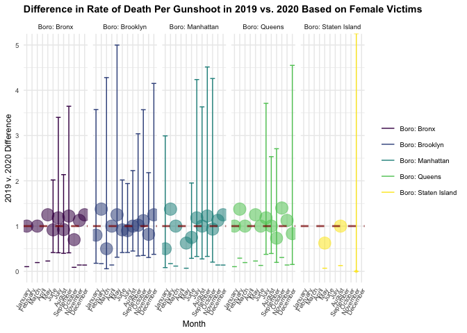

```r
female_data %>%
  filter(term != "(Intercept)") %>%
  mutate(term = str_replace(term, "2019 v. 2020, ", "")) %>%
  ggplot(aes(x = month, y = exp(estimate), color = term)) +
  geom_point(show.legend = FALSE, aes(size = estimate, alpha = .7)) +
  geom_errorbar(aes(ymin = exp(estimate - (1.96*std.error)),
                    ymax = exp(estimate + (1.96*std.error)))) +
  geom_hline(yintercept = 1, linetype="dashed",
                color = "darkred", size = 1, alpha = .7) +
  labs(
    title = "Difference in Rate of Death Per Gunshoot in 2019 vs. 2020 Based on Female Victims",
    x = "Month",
    y = "2019 v. 2020 Difference"
  ) +
  ylim(0, 5) +
  theme(legend.position="right", legend.title = element_blank(),
        text = element_text(size = 9),
        axis.text.x = element_text(angle = 60, hjust = 1, size = 7)) +
  facet_grid(. ~ term)
```

Based on the figure above, also no majot discernable pattern was covered, suggesting that rates of death per gunshoot did not differ between 2019 and 2020 in female victims.

## Summary

In conclusion, there was no major evidence that rates of death per gunshoot differed between 2019 and 2020 for gunshoot that involved either male or female.

### assorted version

```r
my_data = mydata %>%
  filter(year %in% c(2019,2020)) %>%
  mutate(boro = str_to_title(boro)) %>%
  group_by(year) %>%
  mutate(year = year - 2019) %>%
  nest(data = -month) %>%
  mutate(models = map(data, ~glm( statistical_murder_flag~ year:boro,
                                 family = "poisson", data = .x)),
         models = map(models, broom::tidy)) %>%
  dplyr::select(-data) %>%
  unnest(models) %>%
  dplyr::select(month, term, estimate, std.error, p.value) %>%
  mutate(term = str_replace(term, "year:boro", "Boro: ")) %>%
  left_join(month_df, by = "month") %>%
  dplyr::select(-month) %>%
  rename(month = month_name) %>%
  dplyr::select(month, everything())
```

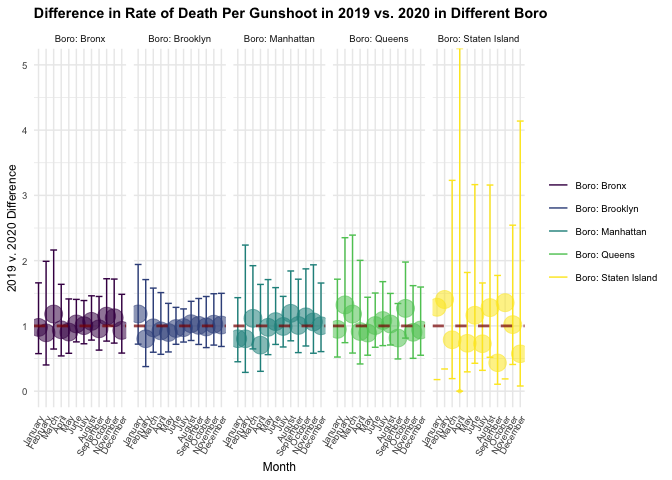

```r
my_data %>%
  filter(term != "(Intercept)") %>%
  mutate(term = str_replace(term, "2019 v. 2020, ", "")) %>%
  ggplot(aes(x = month, y = exp(estimate), color = term)) +
  geom_point(show.legend = FALSE, aes(size = estimate, alpha = .7)) +
  geom_errorbar(aes(ymin = exp(estimate - (1.96*std.error)),
                    ymax = exp(estimate + (1.96*std.error)))) +
  geom_hline(yintercept = 1, linetype="dashed",
                color = "darkred", size = 1, alpha = .7) +
  labs(
    title = "Difference in Rate of Death Per Gunshoot in 2019 vs. 2020 in Different Boro",
    x = "Month",
    y = "2019 v. 2020 Difference"
  ) +
  ylim(0, 5) +
  theme(legend.position="right", legend.title = element_blank(),
        text = element_text(size = 9),
        axis.text.x = element_text(angle = 60, hjust = 1, size = 7)) +
  facet_grid(. ~ term)
```